# Rmarkdown Features

This is subtitle

Yongfu Liao

## yaml Setup

yaml metadata determines the output file format, looking, and any other additional customizing features of Rmarkdown files.

### yaml of this Doc

This is the complete yaml header of this document.

```yaml
---
title: "Rmarkdown Features"
subtitle: "This is subtitle"
author: Yongfu Liao
date: March 18, 2018
bibliography: /Users/user/local_depend/citation/neanderthals.bib
csl: /Users/user/local_depend/style_sheets/apa-no-doi-no-issue.csl
link-citations: yes
output:
  html_document:
    code_folding: show
    css: /Users/user/local_depend/style_sheets/style.css
    df_print: kable
    toc: true
    toc_depth: 3
    toc_float:
        collapsed: false
---
```

### HTML Output

```yaml
output:
  html_document:
    css: ../style_sheets/style.css
    df_print: kable
    code_folding: hide
    fig_width: 7
    fig_height: 6
    toc: true
    toc_depth: 4
    toc_float: true
```

### PDF Output

You may need to attatch an additional `header.tex` and set `latex_engine` to `xelatex` for PDF documents containing multibite characters (e.g. Chinese). Read more about header.txt.

```yaml
---
output:
  pdf_document:
    latex_engine: xelatex
    includes:
        in_header: header.tex
documentclass: article
urlcolor: "blue"
fontsize: 12pt
---
```

### PDF: header.tex

The code below is for generating PDF documents written in (Traditional) Chinese.

```latex
%加這個就可以設定字體
\usepackage{fontspec}
%使用xeCJK，其他的還有CJK或是xCJK
\usepackage{xeCJK}

%設定英文字型，不設的話就會使用預設的字型
\setmainfont{Calibri}

%設定中英文的字型
%字型的設定可以使用系統內的字型，而不用像以前一樣另外安裝
\setCJKmainfont{蘋方-繁}

%中文自動換行
\XeTeXlinebreaklocale "zh"

%文字的彈性間距
\XeTeXlinebreakskip = 0pt plus 1pt

%設定段落之間的距離
\setlength{\parskip}{0.15cm}

%設定行距
\linespread{1.2}\selectfont
```

### Bibliography

```yaml
bibliography: ./citation/neanderthals.bib
csl: ./citation/apa-no-doi-no-issue.csl # APA style sheet
link-citations: yes
```

For citation syntax, read the section Bibliography & Citations.

## Dynamic Variables

Include **R Code Chunks’ Variables** in the body of text.

```r
alpha <- 1:3
text <- c("a", "b")
```

1. The numeric variable $\alpha =$ 1.

   ```yaml
   # The numeric variable $\alpha =$ `r alpha[1]`.
   ```

2. The string variable $text =$ a.

   ```yaml
   # The string variable $text =$ `r text[1]`.
   ```

## $\LaTeX$ Math Rendering

### Passing Matrix Object

#### Setup

Add `results='asis'` to r code chunk option.

```r
library(mat2tex)
mt <- c(1,2)
"$A =" %_% xm(mt,0) %_%"_{2 \\times 1}$"
```

$A = \begin{pmatrix} 1 \\ 2 \\ \end{pmatrix} _{2 \times 1}$

#### Include Matrix in Text

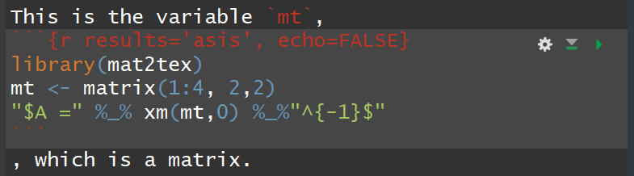

renders as:

This is the variable `mt`, $A = \begin{pmatrix} 1 & 3 \\ 2 & 4 \\ \end{pmatrix} ^{-1}$ , which is a matrix.

Check [here](http://markheckmann.github.io/mat2tex/) for more information.

### kable

```r
library(knitr)
library(dplyr)
iris_data <- head(iris) %>%
    select(Sepal.Length, Sepal.Width)

colnames(iris_data) <- c("$\\alpha$", "$\\frac{a}{b}$")
kable(iris_data, format = "markdown", align = "c")
```

| $\alpha$ | $\frac{a}{b}$ |
| --- | --- |
| 5.1 | 3.5 |
| 4.9 | 3.0 |
| 4.7 | 3.2 |
| 4.6 | 3.1 |
| 5.0 | 3.6 |
| 5.4 | 3.9 |

### Plotting Expression

```r
library(latex2exp)
library(ggplot2)
iris_data2 <- iris[c(1:3, 50:53, 100:103), ] %>%
    select(Sepal.Length, Sepal.Width, Species)

iris_data2 %>% ggplot() +
    geom_point(aes(x = Sepal.Length,
                   y = Sepal.Width,
                   color = Species)) +
    labs(x = TeX("Length($\\frac{kg}{cm^2}$)"),
         y = TeX("\\frac{a}{b}"))
```

[figure not shown]

## Bibliographies & Citations

You can read the full documentation of [Bibliographies & Citations](https://rmarkdown.rstudio.com/authoring_bibliographies_and_citations.html) at Rstudio.

### Citation syntax

#### Classical Citation: **Author**, **year**, and **brackets**

- `Some text [@Bib.ID].`
  - Some text (Abadia & Gonzalez Morales, 2010).

#### In-text Citation: **Author (year)**

- `@Bib.ID Some text`
  - Csikszentmihalyi (2014) Some text
- `@Bib.ID [p. 20] Some text.`
  - Abadia & Gonzalez Morales (2010, p. 20) Some text.

#### Year only: Suppress Author

- `Some text [-@Bib.ID].`
  - Some text (2010)

#### Two Citations

- `Some text [@Bib.ID1; @Bib.ID2].`
  - Some text (Abadia & Gonzalez Morales, 2010; Csikszentmihalyi, 2014).
5. Prefix & Suffix
   - `Some text [see @Bib.ID1 pp.45; also, @Bib.ID2 ch. 2].`
     - Some text (see Abadia & Gonzalez Morales, 2010, p. 45; also, Csikszentmihalyi, 2014 ch. 2).

### Include `.bib` file in Reference

Rmarkdown requires specific formats of bibliographies. One of the most common one is `.bib`. A lot of people (including me) use Endnote to manage bibliographies and have no time getting used to other open source reference managers. Read [this](https://libguides.usask.ca/c.php?g=218034&p=1458583) to see how to generate `.bib` from EndNote.

Below are some syntax in Rmarkdown to control the display of reference in the document.

#### Reference heading

The body of cited reference in the `.bib` file will be shown under the header named Reference (it doesn’t matter which **level** of heading you use).

```markdown
## Reference
```

#### Specific Refs

Include specific references that were **not cited** in the body of text.

```
---
nocite: |
  @item1, @item2
...
```

#### All Refs

Include **All references** in the body of text.

```
---
nocite: |
  @*
...
```

## Emphasis

### An Example

````markdown
```{block2, type="success"}
| This is line 1, pragraph one. [**Red text**]{.red}. Text text text text.
| This is [line 2]{style="color:rgba(255, 0, 0, 1)"} of paragraph one.

Paragraph two starts here.
```
````

This is line 1, pragraph one. **Red text**. Text text text text. This is line 2 of paragraph one.

Paragraph two starts here.

### Colored divs

#### Bootstrap Alert

You can use bootstrap’s default alert divs in Rmarkdown, defined with four classes:

1. alert alert-success
2. alert alert-warning
3. alert alert-info
4. alert alert-danger

````markdown
```{block, type="alert alert-success"}
Bootstrap-defined colored region
```
````

Bootstrap-defined colored region

#### Customized divs

Alternative, you can define your own styled divs, as in my stylesheet[^1]:

There are 4 choices of classes,

1. success
2. warning
3. info
4. error

````markdown
```{block, type="info"}
some text in the colored region
```
````

some text in the colored region

### Bootstrap Callouts

Althougt it’s “Bootstrap” callouts, it’s not contained in default bootstrap theme. I defined it in my stylesheet.

There are 4 choices of classes,

1. bs-callout bs-callout-success
2. bs-callout bs-callout-warning
3. bs-callout bs-callout-info
4. bs-callout bs-callout-error

````markdown
```{block2, type="bs-callout bs-callout-warning"}
#### Heading in Callout
**Calleout Text** texttexttexttexttexttext
```
````

#### Heading in Callout

**Calleout Text** texttexttexttexttexttext

### New Line

```markdown
| Text of line 1
| Text of line 2

New paragraph
```

Text of line 1 Text of line 2

New paragraph

### Attach Attributes

By using `[`text`]`, pandoc turns the text in the square brackets into the HTML `<span>` tag. HTML `class`, `id`, attributes specific to `<span>` can then be attached by using the curly braces.

#### `class`

Rmarkdown syntax allows attaching attributes (such as class, id, etc.) to certain elements by wrapping attributes into `{ ... }`.

Elements allowed attributes to be attach (by markdown syntax directly):

1. Section: Attributes are added next to **any level of heading**.
2. Link: `[Text](LINK){attributes}`
3. `span`: Text wrapped in `[`, `]`. e.g `[Text with class "red"]{.red}`.

```markdown
[**Red Bold text**]{.red}
```

**Red Bold text**

Note[^2].

#### Other Attributes

```markdown
Add color through [span style]{style="color:rgba(255, 0, 0, 1)"}
```

Add color through span style

## Footnotes with Paragraphs

Check [Pandoc](http://pandoc.org/MANUAL.html#footnotes) for details.

```markdown
[^longnote]: Here's one with multiple blocks.

    Subsequent paragraphs are indented to show that they belong to the previous footnote. (JUST IGNORE ME, I AM Exteeeeeendiiiiiiing the text to show the effect of paragraph).

    In this way, multi-paragraph footnotes work like multi-paragraph list items.
```

- Read the output by clicking the superscript[^3].

## Shaped Images

### Rounded Edge

```markdown
![](../../local_depend/icons/libreoffice.ico){width=auto height="30%" .rounded}
```

[figure not shown]

#### Boostrap

```markdown
![](../../local_depend/icons/libreoffice.ico){width=auto height="30%" .img-rounded}
```

[figure not shown]

Bootstrap Rounded

### Circle Image

```markdown
![](../../local_depend/icons/libreoffice.ico){width=auto height="30%" .circle}
```

[figure not shown]

This is figure Caption

#### Boostrap

```markdown
![](../../local_depend/icons/libreoffice.ico){width=auto height="30%" .img-circle}
```

[figure not shown]

Bootstrap Circle

### Thumbnail

```markdown
![](../../local_depend/icons/libreoffice.ico){width=auto height="30%" .img-thumbnail}
```

[figure not shown]

Bootstrap Thumbnail

## Figures

### Captions

Include `fig.cap='An Caption of the Plot'` in the code chunk option gives:

```r
library(ggplot2)
ggplot(iris)+
    geom_point(aes(x=Sepal.Length, y=Sepal.Width, color=Species))
```

[figure not shown]

An Caption of the Plot

## References

Abadia, O. M., & Gonzalez Morales, M. R. (2010). Redefining neanderthals and art: An alternative interpretation of the multiple species model for the origin of behavioural modernity. *Oxford Journal of Archaeology*, *29*, 229–243. Journal Article.

Csikszentmihalyi, M. (2014). Society, culture, and person: A systems view of creativity. In *The systems model of creativity: The collected works of mihaly csikszentmihalyi* (pp. 47–61). Book Section, Dordrecht: Springer Netherlands.

[^1]: Look at my [stylesheet](https://github.com/liao961120/local_depend/blob/master/style_sheets/style.css) for syntax details.
[^2]: `.red` is also a self-defined class in my stylesheet.
[^3]: Here’s one with multiple blocks.

    Subsequent paragraphs are indented to show that they belong to the previous footnote. (JUST IGNORE ME, I AM Exteeeeeendiiiiiiing the text to show the effect of paragraph).

    In this way, multi-paragraph footnotes work like multi-paragraph list items.